# TL-20-0B6792 SYGNOMICS Report

01/09/2022

|  | Patient ID | Age | Sex | MGMT Methylation | ExomeSeq | RNASeq | CNV | Profiling Type |
| --- | --- | --- | --- | --- | --- | --- | --- | --- |
| 1 | TL-20-0B6792 |  |  | Methylated | Yes | Yes | Yes | Unknown |

# FDA Approved Drugs

# 1. Target: APP

### Drugs

|  | Drug | Drug Action | Toxicity Class | Max GBM Phase | FDA Approved | Clinical Trials |
| --- | --- | --- | --- | --- | --- | --- |
| 1 | PONEZUMAB | BINDING AGENT |  | 0 | TRUE | Clinical Trials |
| 2 | GSK933776 | BINDING AGENT |  | 0 | TRUE | Clinical Trials |
| 3 | BAPINEUZUMAB | BINDING AGENT |  | 0 | TRUE | Clinical Trials |
| 4 | GANTENERUMAB | BINDING AGENT |  | 0 | TRUE | Clinical Trials |
| 5 | SOLANEZUMAB | BINDING AGENT |  | 0 | TRUE | Clinical Trials |
| 6 | ADUCANUMAB | BINDING AGENT |  | 0 | TRUE | Clinical Trials |
| 7 | LECANEMAB | INHIBITOR |  | 0 | TRUE | Clinical Trials |
| 8 | CRENEZUMAB | INHIBITOR |  | 0 | TRUE | Clinical Trials |

### Model Evidence

**41** regulons containing the target(s), **APP** are overactive in this patient.

### Hallmarks Enrichment

HALLMARK_ANGIOGENESIS HALLMARK_TNFA_SIGNALING_VIA_NFKB

### Literature Evidence

|  | Gene | Evidence | Disease | Title | PMID | Year | Type |
| --- | --- | --- | --- | --- | --- | --- | --- |
| 1 | APP | cyclooxygenase-2 (COX-2), cytosolic phospholipase, interleukin-1(IL-1), and the -amyloid precursor protein of proinflammatory and neurodegenerative gene were found to be upregulated in the American Ti… | GBM | Molecular Characteristics of Amyloid Precursor Protein (APP) and Its Effects in Cancer | 34066808 | 2021 | Publication |
| 2 | APP | Upregulation of beta-amyloid precursor protein expression in glioblastoma multiforme | GBM | Upregulation of beta-amyloid precursor protein expression in glioblastoma multiforme | 18521005 | 2008 | Publication |
| 3 | APP | Accumulation of Innate Amyloid Beta Peptide in Glioblastoma Tumors | GBM | Accumulation of Innate Amyloid Beta Peptide in Glioblastoma Tumors | 31137462 | 2019 | Publication |

### Glioblastoma Clinical Trials

No glioblastoma clinical trials were found for these drugs.

### Network Plots

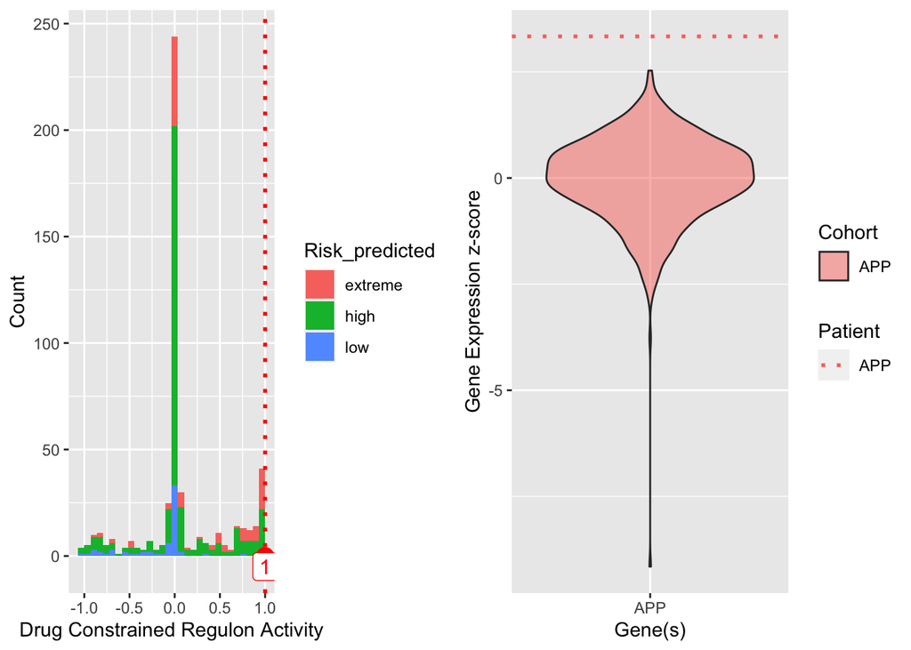

# 2. Target: HBB

### Drugs

[output not shown]

### Model Evidence

**2** regulons containing the target(s), **HBB** are overactive in this patient.

### Hallmarks Enrichment

None

### Literature Evidence

No additional evidence was found

### Glioblastoma Clinical Trials

|  | NCT.Number | Title | Status | Interventions | Phases | First.Posted |
| --- | --- | --- | --- | --- | --- | --- |
| 1 | NCT00005855 | Efaproxiral Plus Carmustine in Treating Patients With Progressive or Recurrent Malignant Glioma | Completed | Drug: carmustine\|Drug: efaproxiral | Phase 1\|Phase 2 | 27-Jan-03 |

### Network Plots

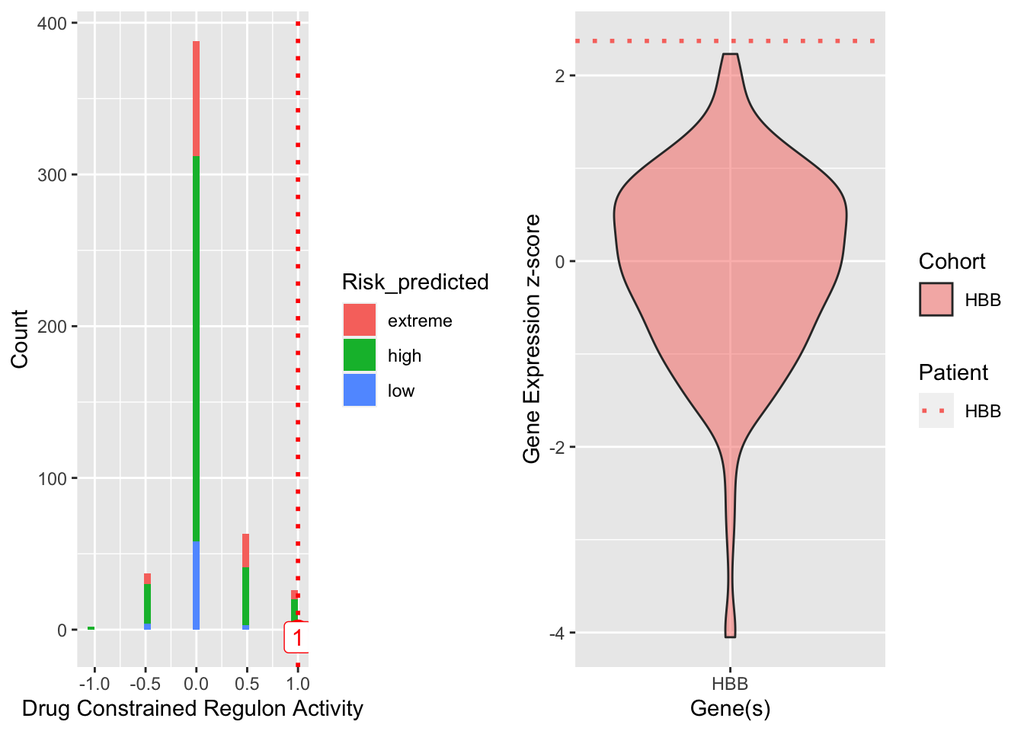

# 3. Target: VKORC1

### Drugs

|  | Drug | Drug Action | Toxicity Class | Max GBM Phase | FDA Approved | Clinical Trials |
| --- | --- | --- | --- | --- | --- | --- |
| 1 | WARFARIN | INHIBITOR | Vascular toxicity Carcinogenicity | 0 | TRUE | Clinical Trials |
| 2 | DICUMAROL | INHIBITOR |  | 0 | TRUE | Clinical Trials |
| 3 | PHENINDIONE | INHIBITOR |  | 0 | TRUE | Clinical Trials |
| 4 | ACENOCOUMAROL | INHIBITOR |  | 0 | TRUE | Clinical Trials |
| 5 | PHENPROCOUMON | INHIBITOR |  | 0 | TRUE | Clinical Trials |
| 6 | WARFARIN SODIUM | INHIBITOR | Vascular toxicity Carcinogenicity | 0 | TRUE | Clinical Trials |
| 7 | WARFARIN POTASSIUM | INHIBITOR |  | 0 | TRUE | Clinical Trials |

### Model Evidence

**2** regulons containing the target(s), **VKORC1** are overactive in this patient.

### Hallmarks Enrichment

HALLMARK_UNFOLDED_PROTEIN_RESPONSE

### Literature Evidence

No additional evidence was found

### Glioblastoma Clinical Trials

No glioblastoma clinical trials were found for these drugs.

### Network Plots

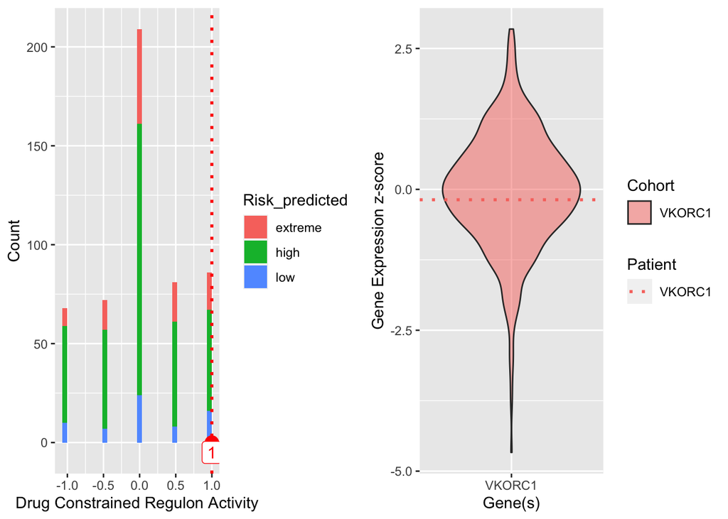

# 4. Target: SERPINE1

### Drugs

|  | Drug | Drug Action | Toxicity Class | Max GBM Phase | FDA Approved | Clinical Trials |
| --- | --- | --- | --- | --- | --- | --- |
| 1 | ALEPLASININ | INHIBITOR |  | 0 | TRUE | Clinical Trials |

### Model Evidence

**56** regulons containing the target(s), **SERPINE1** are overactive in this patient.

### Hallmarks Enrichment

HALLMARK_EPITHELIAL_MESENCHYMAL_TRANSITION HALLMARK_TNFA_SIGNALING_VIA_NFKB HALLMARK_COMPLEMENT HALLMARK_APOPTOSIS HALLMARK_TGF_BETA_SIGNALING HALLMARK_UV_RESPONSE_DN HALLMARK_PROTEIN_SECRETION HALLMARK_INFLAMMATORY_RESPONSE

### Literature Evidence

No additional evidence was found

### Glioblastoma Clinical Trials

No glioblastoma clinical trials were found for these drugs.

### Network Plots

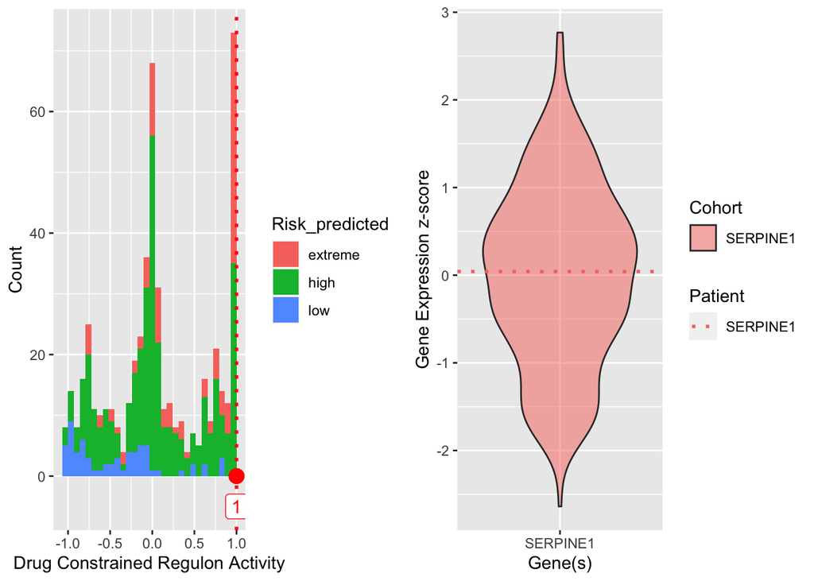

# 5. Target: DPYD

### Drugs

|  | Drug | Drug Action | Toxicity Class | Max GBM Phase | FDA Approved | Clinical Trials |
| --- | --- | --- | --- | --- | --- | --- |
| 1 | ENILURACIL | INHIBITOR |  | 0 | TRUE | Clinical Trials |

### Model Evidence

**8** regulons containing the target(s), **DPYD** are overactive in this patient.

### Hallmarks Enrichment

HALLMARK_COAGULATION

### Literature Evidence

No additional evidence was found

### Glioblastoma Clinical Trials

No glioblastoma clinical trials were found for these drugs.

### Network Plots

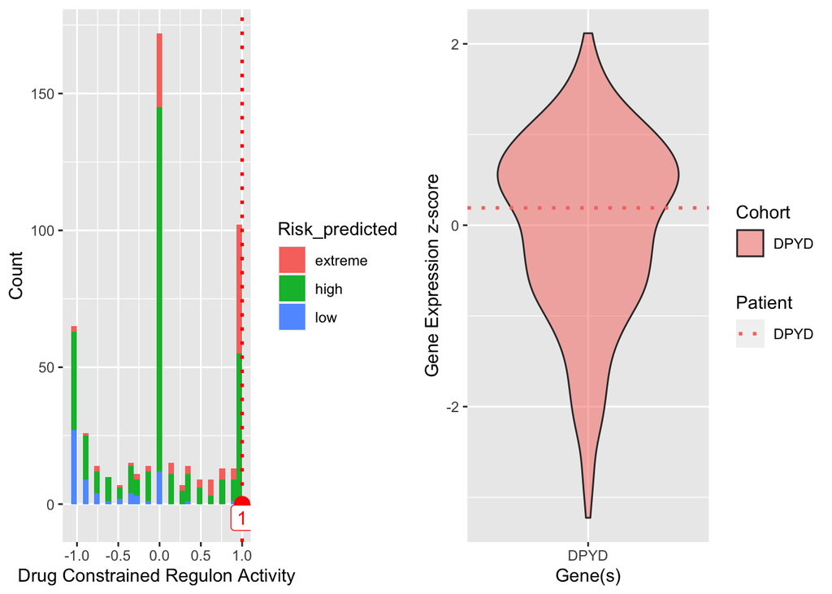

# 6. Target: ABL1

### Drugs

|  | Drug | Drug Action | Toxicity Class | Max GBM Phase | FDA Approved | Clinical Trials |
| --- | --- | --- | --- | --- | --- | --- |
| 1 | FLUMATINIB | INHIBITOR |  | 0 | TRUE | Clinical Trials |
| 2 | NILOTINIB HYDROCHLORIDE MONOHYDRATE | INHIBITOR |  | 0 | TRUE | Clinical Trials |
| 3 | REBASTINIB | INHIBITOR |  | 0 | TRUE | Clinical Trials |
| 4 | NILOTINIB | INHIBITOR | Cardiotoxicity | 0 | TRUE | Clinical Trials |
| 5 | ASCIMINIB | INHIBITOR |  | 0 | TRUE | Clinical Trials |

### Model Evidence

**5** regulons containing the target(s), **ABL1** are overactive in this patient.

### Hallmarks Enrichment

HALLMARK_MITOTIC_SPINDLE HALLMARK_G2M_CHECKPOINT

### Literature Evidence

|  | Gene | Evidence | Disease | Title | PMID | Year | Type |
| --- | --- | --- | --- | --- | --- | --- | --- |
| 1 | ABL1 | identify ABL as a crucial player for migration, invasion, proliferation, tumorigenic, and stem-cell like properties of GBM cells. Taken together, this work supports the notion that the oncogenic role … | GBM | Coordination of signalling networks and tumorigenic properties by ABL in glioblastoma cells | 27732969 | 2016 | Publication |
| 2 | ABL1 | Imatinib and nilotinib-induced tyrosine phosphorylation was dependent on expression of p130Cas and FAK activity and was independent of known imatinib targets including Abl, platelet derived growth fac… | GBM | Imatinib and Nilotinib increase glioblastoma cell invasion via Abl-independent stimulation of p130Cas and FAK signalling | 27293031 | 2016 | Publication |

### Glioblastoma Clinical Trials

No glioblastoma clinical trials were found for these drugs.

### Network Plots

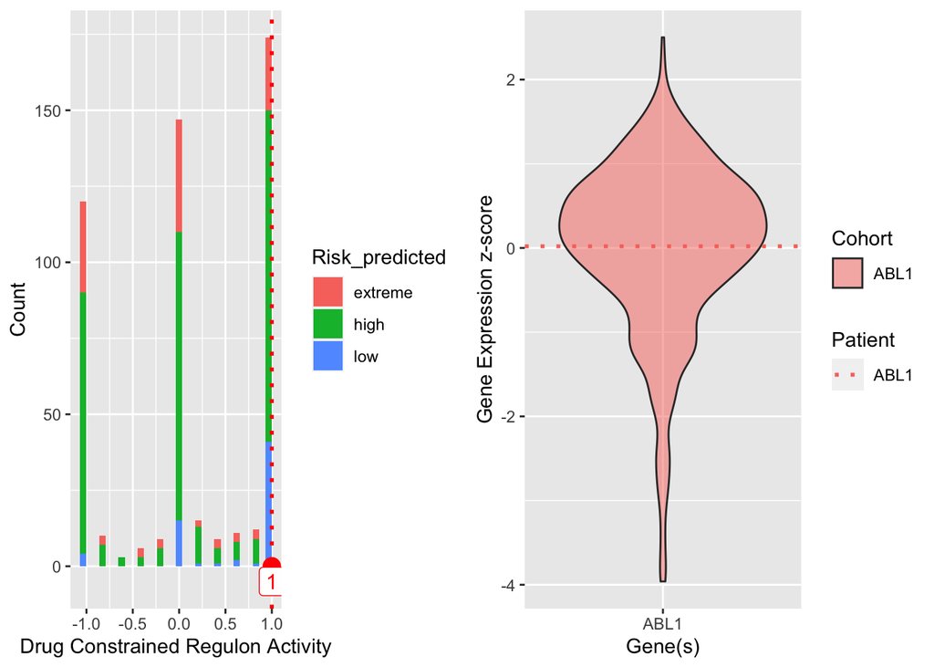

# 7. Target: LOXL2

### Drugs

|  | Drug | Drug Action | Toxicity Class | Max GBM Phase | FDA Approved | Clinical Trials |
| --- | --- | --- | --- | --- | --- | --- |
| 1 | SIMTUZUMAB | INHIBITOR |  | 0 | TRUE | Clinical Trials |

### Model Evidence

**1** regulons containing the target(s), **LOXL2** are overactive in this patient.

### Hallmarks Enrichment

HALLMARK_UNFOLDED_PROTEIN_RESPONSE

### Literature Evidence

No additional evidence was found

### Glioblastoma Clinical Trials

No glioblastoma clinical trials were found for these drugs.

### Network Plots

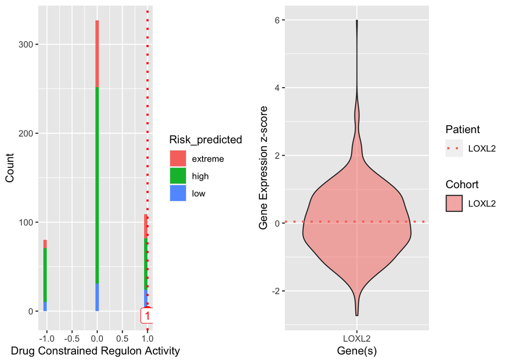

# 8. Target: BSG

### Drugs

|  | Drug | Drug Action | Toxicity Class | Max GBM Phase | FDA Approved | Clinical Trials |
| --- | --- | --- | --- | --- | --- | --- |
| 1 | GAVILIMOMAB | OTHER |  | 0 | TRUE | Clinical Trials |

### Model Evidence

**2** regulons containing the target(s), **BSG** are overactive in this patient.

### Hallmarks Enrichment

None

### Literature Evidence

No additional evidence was found

### Glioblastoma Clinical Trials

No glioblastoma clinical trials were found for these drugs.

### Network Plots

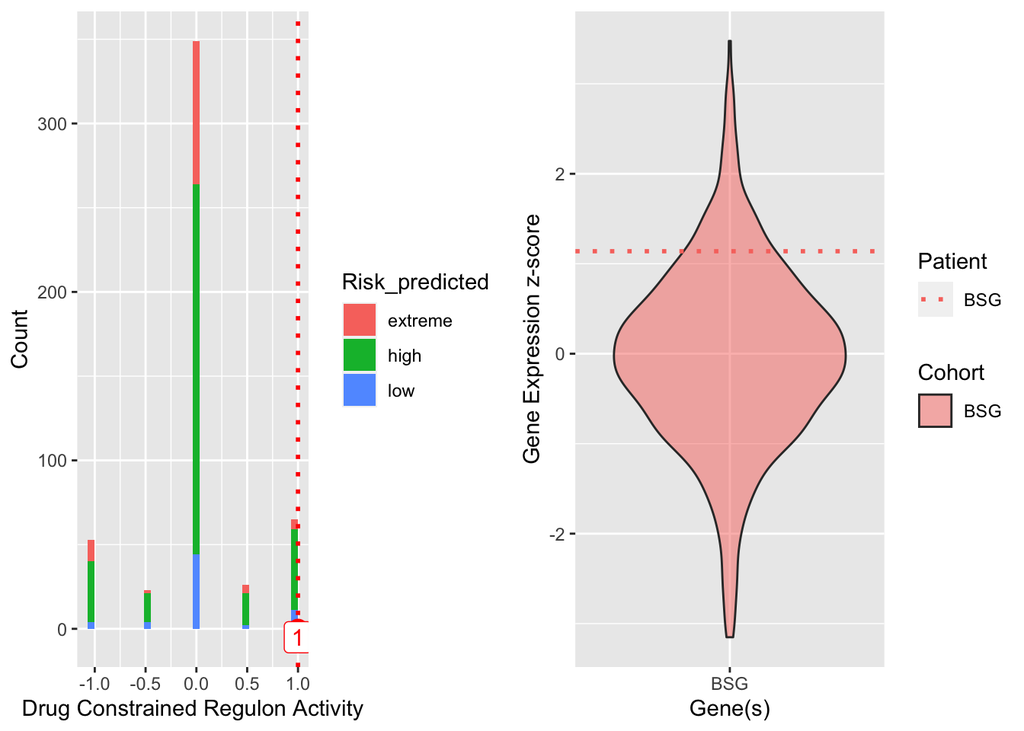

# 9. Target: NDUFA13

### Drugs

|  | Drug | Drug Action | Toxicity Class | Max GBM Phase | FDA Approved | Clinical Trials |
| --- | --- | --- | --- | --- | --- | --- |
| 1 | ME-344 | INHIBITOR |  | 0 | TRUE | Clinical Trials |

### Model Evidence

**5** regulons containing the target(s), **NDUFA13** are overactive in this patient.

### Hallmarks Enrichment

HALLMARK_OXIDATIVE_PHOSPHORYLATION HALLMARK_DNA_REPAIR HALLMARK_MYC_TARGETS_V1

### Literature Evidence

|  | Gene | Evidence | Disease | Title | PMID | Year | Type |
| --- | --- | --- | --- | --- | --- | --- | --- |
| 1 | NDUFA13 | In addition, recent relevant studies have also shown that some candidate tumor gene biomarkers were recognized as targets of glioma, and 4 genes (NDUFS5, NDUFA1, NDUFA13, and NDUFB8) of the candidate … | GBM | Gene biomarker prediction in glioma by integrating scRNA-seq data and gene regulatory network | 34863158 | 2021 | Publication |

### Glioblastoma Clinical Trials

No glioblastoma clinical trials were found for these drugs.

### Network Plots

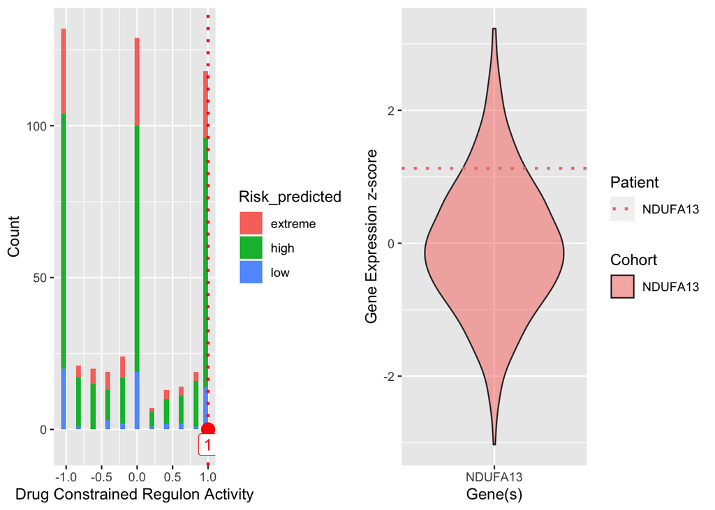

# 10. Target: TSG101

### Drugs

|  | Drug | Drug Action | Toxicity Class | Max GBM Phase | FDA Approved | Clinical Trials |
| --- | --- | --- | --- | --- | --- | --- |
| 1 | FGI-101-1A6 | INHIBITOR |  | 0 | TRUE | Clinical Trials |

### Model Evidence

**2** regulons containing the target(s), **TSG101** are overactive in this patient.

### Hallmarks Enrichment

HALLMARK_OXIDATIVE_PHOSPHORYLATION HALLMARK_DNA_REPAIR HALLMARK_MYC_TARGETS_V1

### Literature Evidence

|  | Gene | Evidence | Disease | Title | PMID | Year | Type |
| --- | --- | --- | --- | --- | --- | --- | --- |
| 1 | TSG101 | The functional studies showed that knockdown of TSG101 suppressed the proliferation, migration, and invasion of glioma cells, while overexpression of TSG101 facilitated them. Mechanistic studies indic… | GBM | TSG101 Promotes the Proliferation, Migration, and Invasion of Human Glioma Cells by Regulating the AKT/GSK3_/_-Catenin and RhoC/Cofilin Pathways | 33411238 | 2021 | Publication |

### Glioblastoma Clinical Trials

No glioblastoma clinical trials were found for these drugs.

### Network Plots

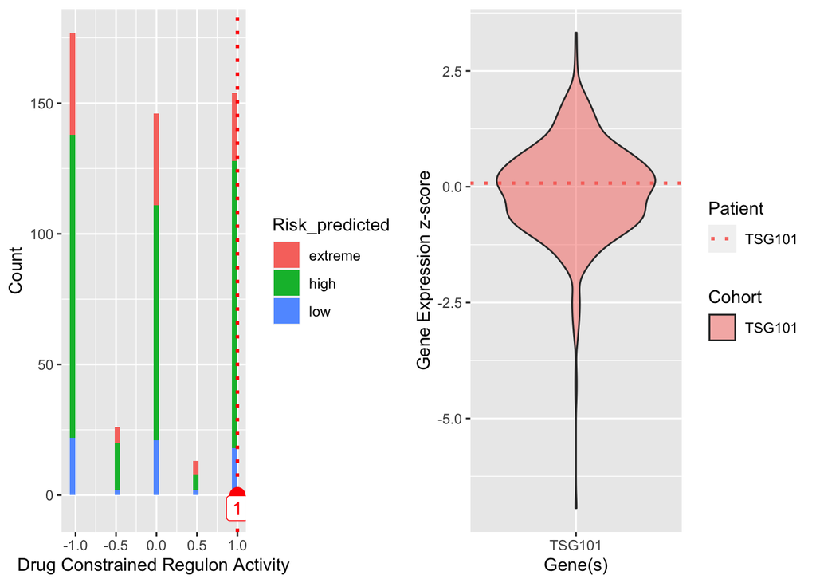

# 11. Target: ITGA2

### Drugs

|  | Drug | Drug Action | Toxicity Class | Max GBM Phase | FDA Approved | Clinical Trials |
| --- | --- | --- | --- | --- | --- | --- |
| 1 | VATELIZUMAB | ANTAGONIST |  | 0 | TRUE | Clinical Trials |

### Model Evidence

**1** regulons containing the target(s), **ITGA2** are overactive in this patient.

### Hallmarks Enrichment

HALLMARK_COAGULATION HALLMARK_APICAL_JUNCTION HALLMARK_EPITHELIAL_MESENCHYMAL_TRANSITION

### Literature Evidence

No additional evidence was found

### Glioblastoma Clinical Trials

No glioblastoma clinical trials were found for these drugs.

### Network Plots

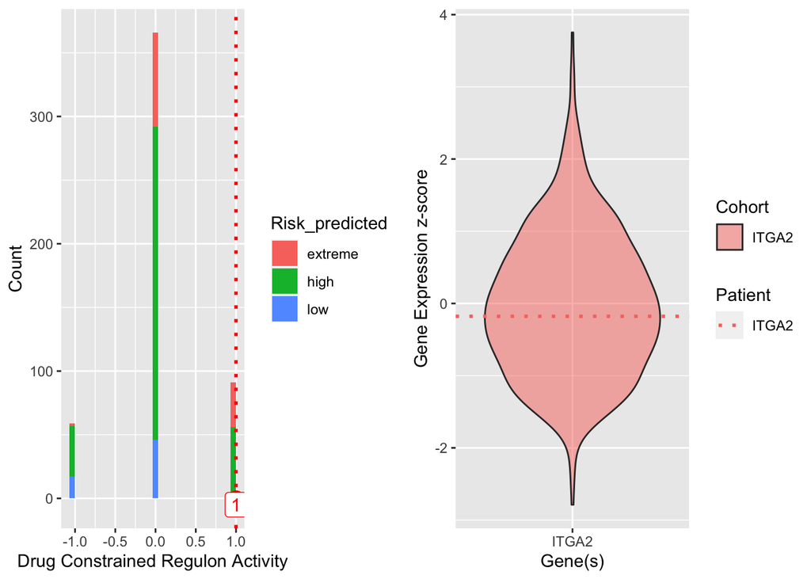

# 12. Target: NCAM1

### Drugs

|  | Drug | Drug Action | Toxicity Class | Max GBM Phase | FDA Approved | Clinical Trials |
| --- | --- | --- | --- | --- | --- | --- |
| 1 | BB-10901 | BINDING AGENT |  | 0 | TRUE | Clinical Trials |
| 2 | LORVOTUZUMAB MERTANSINE | BINDING AGENT |  | 0 | TRUE | Clinical Trials |

### Model Evidence

**1** regulons containing the target(s), **NCAM1** are overactive in this patient.

### Hallmarks Enrichment

None

### Literature Evidence

No additional evidence was found

### Glioblastoma Clinical Trials

No glioblastoma clinical trials were found for these drugs.

### Network Plots

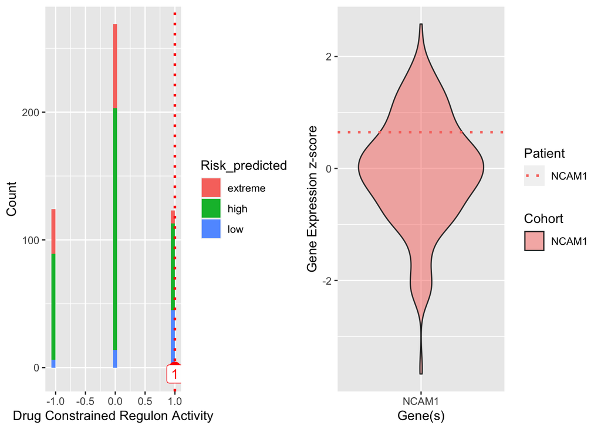

# 13. Target: PLA2G2A

### Drugs

|  | Drug | Drug Action | Toxicity Class | Max GBM Phase | FDA Approved | Clinical Trials |
| --- | --- | --- | --- | --- | --- | --- |
| 1 | VARESPLADIB | INHIBITOR |  | 0 | TRUE | Clinical Trials |

### Model Evidence

**2** regulons containing the target(s), **PLA2G2A** are overactive in this patient.

### Hallmarks Enrichment

None

### Literature Evidence

No additional evidence was found

### Glioblastoma Clinical Trials

No glioblastoma clinical trials were found for these drugs.

### Network Plots

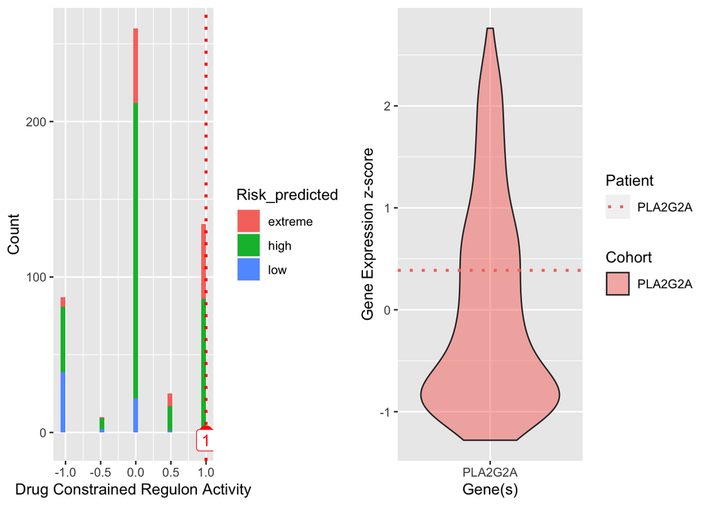

# 14. Target: TRPV4

### Drugs

|  | Drug | Drug Action | Toxicity Class | Max GBM Phase | FDA Approved | Clinical Trials |
| --- | --- | --- | --- | --- | --- | --- |
| 1 | GSK2798745 | ANTAGONIST |  | 0 | TRUE | Clinical Trials |

### Model Evidence

**1** regulons containing the target(s), **TRPV4** are overactive in this patient.

### Hallmarks Enrichment

None

### Literature Evidence

No additional evidence was found

### Glioblastoma Clinical Trials

No glioblastoma clinical trials were found for these drugs.

### Network Plots

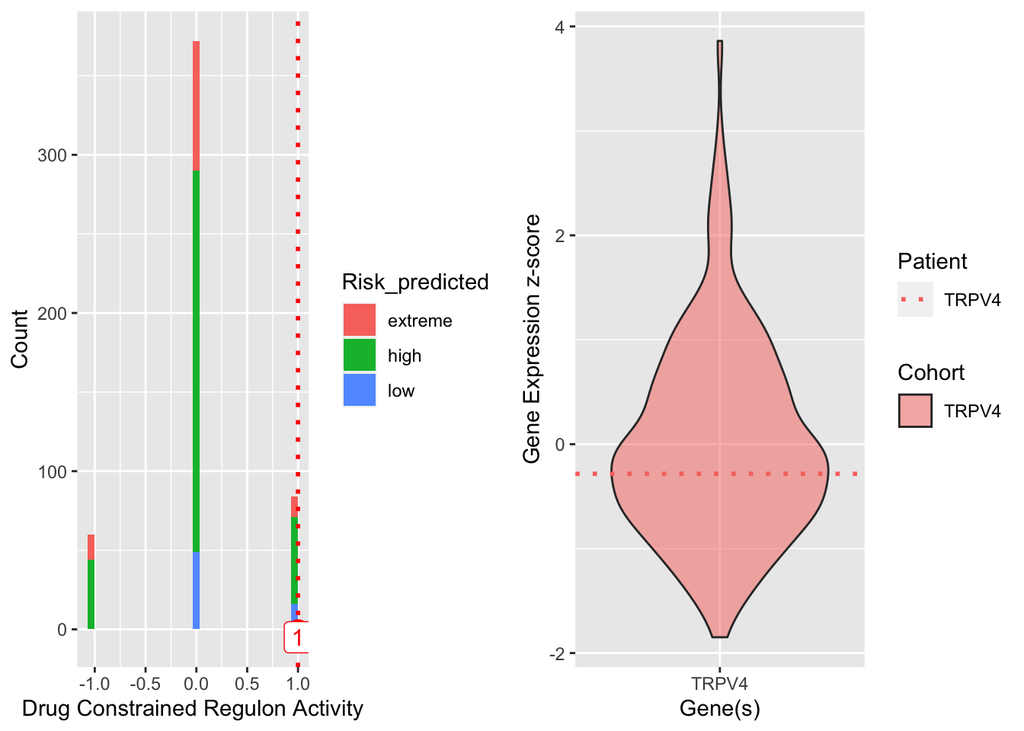

# 15. Target: UGCG

### Drugs

|  | Drug | Drug Action | Toxicity Class | Max GBM Phase | FDA Approved | Clinical Trials |
| --- | --- | --- | --- | --- | --- | --- |
| 1 | ELIGLUSTAT | INHIBITOR |  | 0 | TRUE | Clinical Trials |
| 2 | MIGLUSTAT | INHIBITOR |  | 0 | TRUE | Clinical Trials |
| 3 | ELIGLUSTAT TARTRATE | INHIBITOR |  | 0 | TRUE | Clinical Trials |

### Model Evidence

**50** regulons containing the target(s), **UGCG** are overactive in this patient.

### Hallmarks Enrichment

HALLMARK_ANGIOGENESIS HALLMARK_TNFA_SIGNALING_VIA_NFKB

### Literature Evidence

|  | Gene | Evidence | Disease | Title | PMID | Year | Type |
| --- | --- | --- | --- | --- | --- | --- | --- |
| 1 | UGCG | Silencing of GCS in GBM cells allows to achieve higher levels of cytotoxicity using lower doses of chemotherapeutic drugs. Most importantly, this enhanced cytotoxic effect occurred even in DBTRG cells… | GBM | Glucosylceramide synthase silencing combined with the receptor tyrosine kinase inhibitor axitinib as a new multimodal strategy for glioblastoma | 31518391 | 2019 | Publication |

### Glioblastoma Clinical Trials

No glioblastoma clinical trials were found for these drugs.

### Network Plots

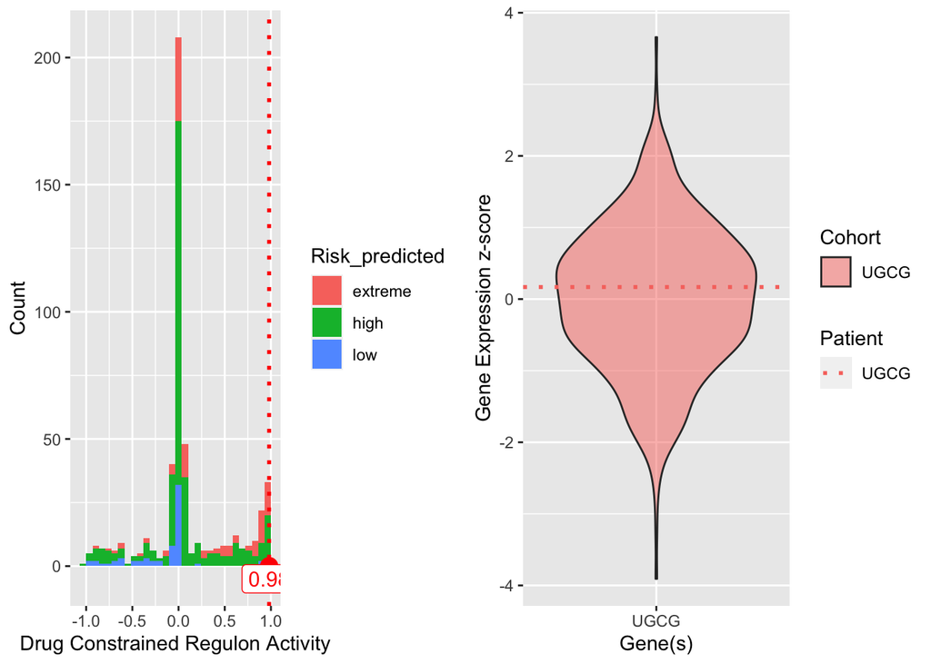

# 16. Target: IFNGR2

### Drugs

|  | Drug | Drug Action | Toxicity Class | Max GBM Phase | FDA Approved | Clinical Trials |
| --- | --- | --- | --- | --- | --- | --- |
| 1 | INTERFERON GAMMA-1B | AGONIST |  | 0 | TRUE | Clinical Trials |

### Model Evidence

**28** regulons containing the target(s), **IFNGR2** are overactive in this patient.

### Hallmarks Enrichment

HALLMARK_EPITHELIAL_MESENCHYMAL_TRANSITION HALLMARK_IL6_JAK_STAT3_SIGNALING HALLMARK_APICAL_JUNCTION HALLMARK_COMPLEMENT HALLMARK_PI3K_AKT_MTOR_SIGNALING

### Literature Evidence

No additional evidence was found

### Glioblastoma Clinical Trials

No glioblastoma clinical trials were found for these drugs.

### Network Plots

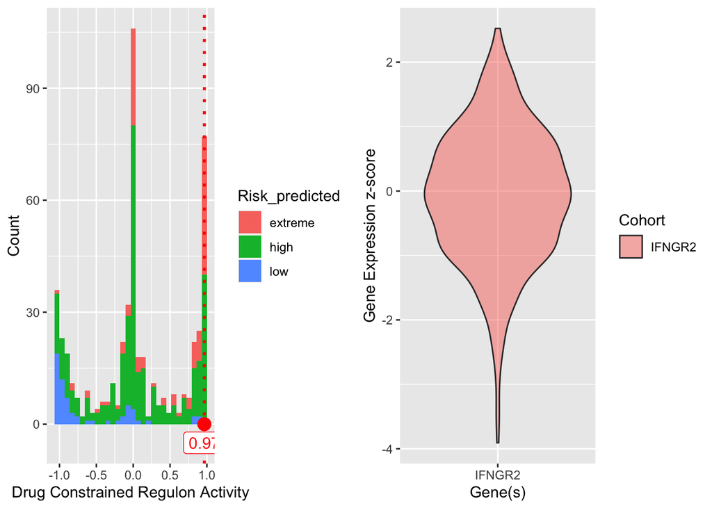

# 17. Target: MAPK1,MAPK3

### Drugs

|  | Drug | Drug Action | Toxicity Class | Max GBM Phase | FDA Approved | Clinical Trials |
| --- | --- | --- | --- | --- | --- | --- |
| 1 | MK-8353 | INHIBITOR |  | 0 | TRUE | Clinical Trials |
| 2 | ULIXERTINIB | INHIBITOR |  | 0 | TRUE | Clinical Trials |
| 3 | RAVOXERTINIB | INHIBITOR |  | 0 | TRUE | Clinical Trials |

### Model Evidence

**19** regulons containing the target(s), **MAPK1,MAPK3** are overactive in this patient.

### Hallmarks Enrichment

None

### Literature Evidence

No additional evidence was found

### Glioblastoma Clinical Trials

|  | NCT.Number | Title | Status | Interventions | Phases | First.Posted |
| --- | --- | --- | --- | --- | --- | --- |
| 1 | NCT04566393 | Expanded Access to Ulixertinib (BVD-523) in Patients With Advanced MAPK Pathway-Altered Malignancies | Available | Drug: Ulixertinib (BVD-523) |  | 28-Sep-20 |

### Network Plots

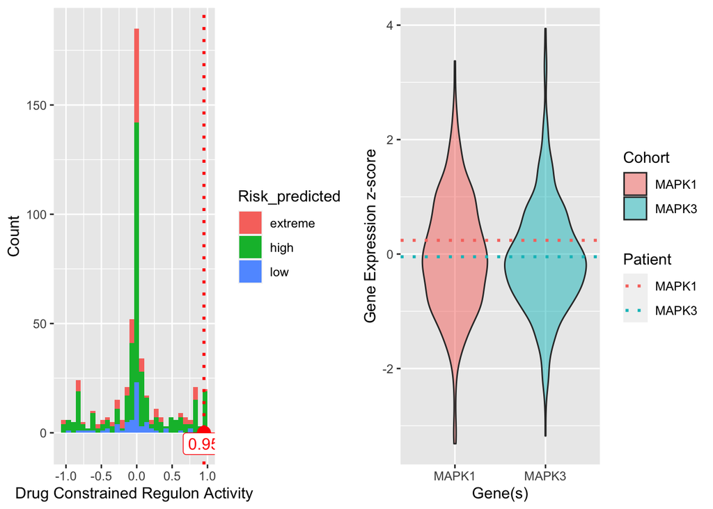

# 18. Target: CCL2

### Drugs

|  | Drug | Drug Action | Toxicity Class | Max GBM Phase | FDA Approved | Clinical Trials |
| --- | --- | --- | --- | --- | --- | --- |
| 1 | CARLUMAB | INHIBITOR |  | 0 | TRUE | Clinical Trials |

### Model Evidence

**12** regulons containing the target(s), **CCL2** are overactive in this patient.

### Hallmarks Enrichment

HALLMARK_COAGULATION

### Literature Evidence

No additional evidence was found

### Glioblastoma Clinical Trials

No glioblastoma clinical trials were found for these drugs.

### Network Plots

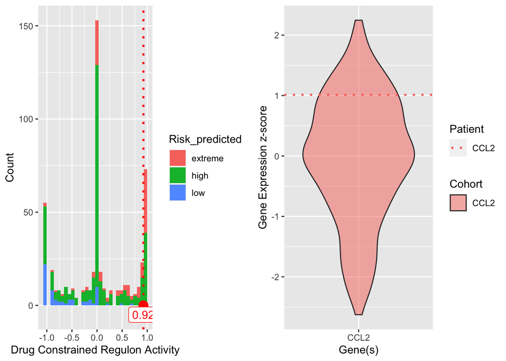

# 19. Target: IL10RB

### Drugs

|  | Drug | Drug Action | Toxicity Class | Max GBM Phase | FDA Approved | Clinical Trials |
| --- | --- | --- | --- | --- | --- | --- |
| 1 | PEGINTERFERON LAMBDA-1A | AGONIST |  | 0 | TRUE | Clinical Trials |

### Model Evidence

**25** regulons containing the target(s), **IL10RB** are overactive in this patient.

### Hallmarks Enrichment

HALLMARK_EPITHELIAL_MESENCHYMAL_TRANSITION HALLMARK_IL6_JAK_STAT3_SIGNALING HALLMARK_APICAL_JUNCTION HALLMARK_COMPLEMENT

### Literature Evidence

No additional evidence was found

### Glioblastoma Clinical Trials

No glioblastoma clinical trials were found for these drugs.

### Network Plots

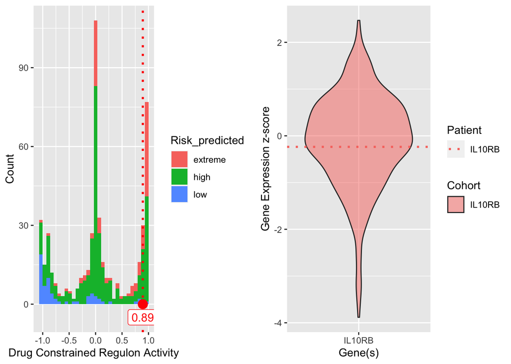

# 20. Target: SOD1

### Drugs

|  | Drug | Drug Action | Toxicity Class | Max GBM Phase | FDA Approved | Clinical Trials |
| --- | --- | --- | --- | --- | --- | --- |
| 1 | TOFERSEN | INHIBITOR |  | 0 | TRUE | Clinical Trials |

### Model Evidence

**5** regulons containing the target(s), **SOD1** are overactive in this patient.

### Hallmarks Enrichment

HALLMARK_OXIDATIVE_PHOSPHORYLATION HALLMARK_ADIPOGENESIS

### Literature Evidence

No additional evidence was found

### Glioblastoma Clinical Trials

No glioblastoma clinical trials were found for these drugs.

### Network Plots

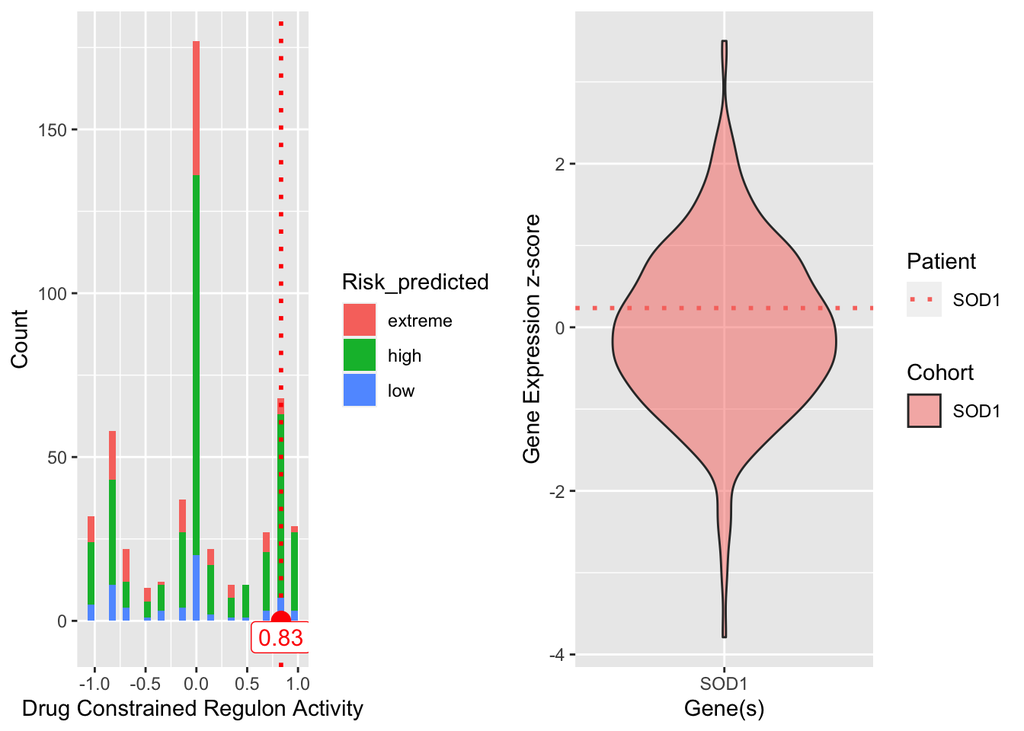

# 21. Target: ACVR2B

### Drugs

|  | Drug | Drug Action | Toxicity Class | Max GBM Phase | FDA Approved | Clinical Trials |
| --- | --- | --- | --- | --- | --- | --- |
| 1 | BIMAGRUMAB | ANTAGONIST |  | 0 | TRUE | Clinical Trials |

### Model Evidence

**5** regulons containing the target(s), **ACVR2B** are overactive in this patient.

### Hallmarks Enrichment

HALLMARK_MITOTIC_SPINDLE HALLMARK_G2M_CHECKPOINT

### Literature Evidence

No additional evidence was found

### Glioblastoma Clinical Trials

No glioblastoma clinical trials were found for these drugs.

### Network Plots

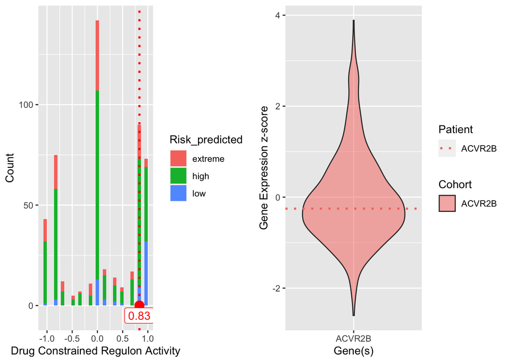

# 22. Target: CD248

### Drugs

|  | Drug | Drug Action | Toxicity Class | Max GBM Phase | FDA Approved | Clinical Trials |
| --- | --- | --- | --- | --- | --- | --- |
| 1 | ONTUXIZUMAB | INHIBITOR |  | 0 | TRUE | Clinical Trials |

### Model Evidence

**9** regulons containing the target(s), **CD248** are overactive in this patient.

### Hallmarks Enrichment

HALLMARK_EPITHELIAL_MESENCHYMAL_TRANSITION HALLMARK_ANGIOGENESIS HALLMARK_UV_RESPONSE_DN HALLMARK_MYOGENESIS

### Literature Evidence

No additional evidence was found

### Glioblastoma Clinical Trials

No glioblastoma clinical trials were found for these drugs.

### Network Plots

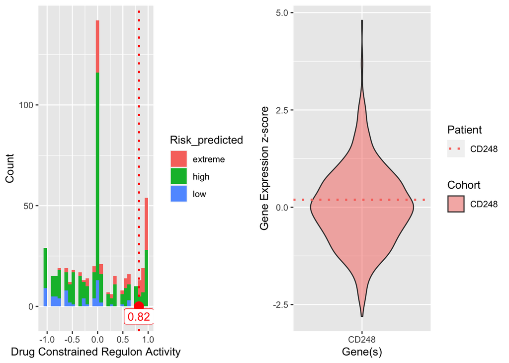